# ba-blog

## COVID-19 and Interventions — Simple Explanation

By Sai Varun Challa, Sahil Chutani, Aditi Garg, Isha Gupta, Neeraj Ramkumar

From human lives to global economies everything is hit by the Corona Virus (COVID-19). Originating from the city of Wuhan in China in 2019, it has left almost no country devoid of it. (yes! Some countries are fortunate such as Tonga, the Republic of Palau as of April 26, 2020). While the whole world is separated by this virus, the same virus unites us strongly too. Great epidemiologists, researchers, and scientists are working hard to find a solution. Being fledgling data scientists, we, students from Columbia University, performed a deeper analysis of the impact of various interventions carried out across the globe. Every country chose its own way to combat the deadly coronavirus. Be it the early detection and contact tracing in South Korea, National Lockdown in New Zealand, and India or uncontrolled spread in Italy — every impact story has something to teach. It is exciting to dive deeper a bit, learn the differences, and visualize the impacts through interactive graphs. Referencing some amazing research papers published recently, we made an attempt to explain the COVID spread, the impact of interventions, and their effect on treating individuals through graphs that anyone can play around with.

#### Basic SIR Model

SIR Model is one of the simplest and highly-used models to understand the effect of COVID-19 around the globe. It divides the population into 3 major compartments —

- Susceptible (that part of the population which hasn’t got infected yet),
- Infected (Infected part of the population) and
- Recovered (that part of the population which has either recovered or died)

Depending on the spread rate of the virus and recovery rate of the population, people move from one compartment to another at different paces. These rates are further affected by the overall nature of the outbreak in the country, interventions carried out, and the success rate of those interventions.

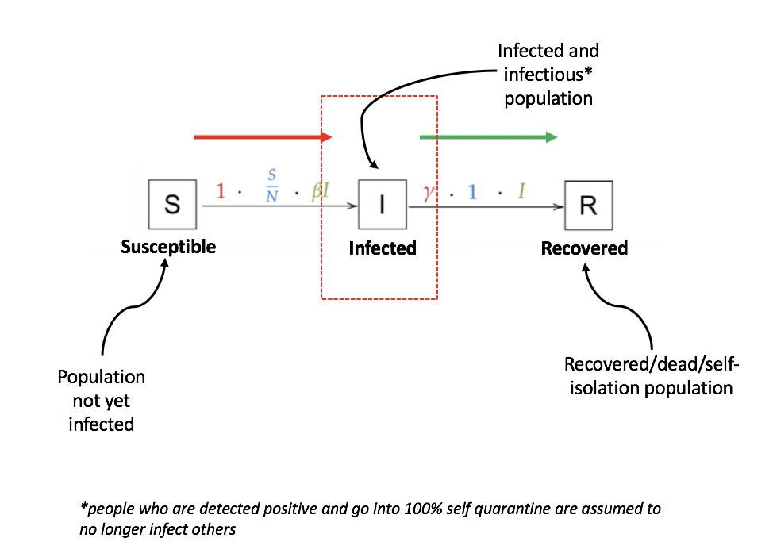

Let’s explain these famous variables which are used to calculate the number of people moving from one compartment to another.

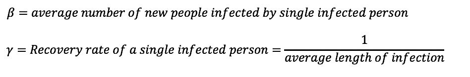

Then the movement of people can be evaluated using these simple equations:

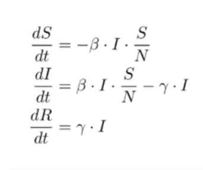

*SIR model equations*

where N is the total population.

As it is evident, the number of people moving from the susceptible to the infected compartment is directly proportional to beta and the number of people moving from the infected to the recovered compartment is directly proportional to gamma.

This leads us to understand the impact of major interventions —

1. National Lockdown and
2. Early Detection,

towards mitigating the effect of ready coronavirus.

#### How do interventions affect these movements?

**Beta Effect:** *National lockdown reduces the average number of people a single human being comes in contact with. Hence, leading to a reduction in the contact rate. Consequently, the average number of people, a single infected person comes in contact with, reduces as well. And hence,* **National lockdown or social distancing reduces the beta i.e. the number of people moving from susceptible to the infected compartment.**

**Gamma Effect:** *Early detection ensures to test every suspected positive case as early as possible. Once a person is detected positive, she/he goes into 100% self-isolation, thus no more being able to infect any other person. Since SIR models use I (number of infected cases) as the number of ‘infectious’ cases, this person is no more infectious and can be assumed to have moved to the recovered compartment — eventually either recovering or dying. And hence,* **Early detection increases gamma i.e. the number of people moving from the infected to the recovered compartment. (Basically, lesser and lesser people are spreading the virus)**

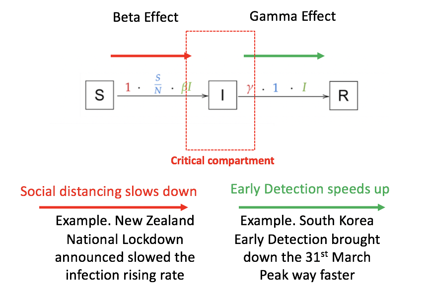

Let’s introduce another important parameter i.e. R_0 which is the Reproduction number depicting the intensity of an infectious disease outbreak. Consequently, R_t is the reproduction number depicting the intensity of the infectious disease in a population at time t. As evident, it is nothing but the ratio of beta and gamma, and hence impacted by interventions itself. The stronger the intervention to check the spread, the steeper is the decline of R_t for the population.

*Here’s a video of an interactive graph we created for you to check how changing beta and gamma, ‘flatten’ the curves.*

[video not shown]

**Feel free to check out this graph on the website below!**

[Interactive Plot](https://dash-app-ba.herokuapp.com)

#### Why flattening the curve is so essential?

As we see in the plot, the larger the peak of curve depicting ‘infected’ people, the larger will be the requirement of beds and ventilators in the hospital. Since no country was prepared for this extent of a pandemic, limited resources are the biggest concern, especially in places like New York, New Jersey where the outbreak is among the worst. Thus, until a vaccine or real treatment is either discovered or invented, flattening the curve is one of the simplest ways to control the number of deaths.

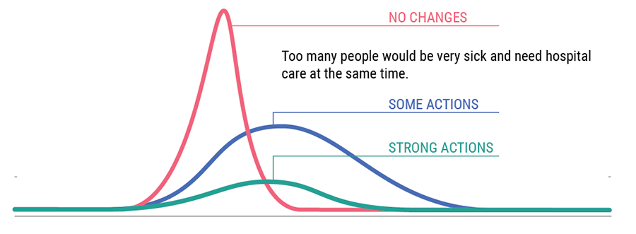

*source: healthwise.org*

#### Modified Model

The infected compartment, as we can expect, isn’t as homogeneous as it sounds. There have been several versions of this SIR model which adds various compartments with different hypotheses. Our analysis was performed by adding 2 separate compartments — Exposed and Dead. On top of it, the Infected compartment was split into 4 components based on severity -Asymptomatic, Mild, Severe, and Critical.

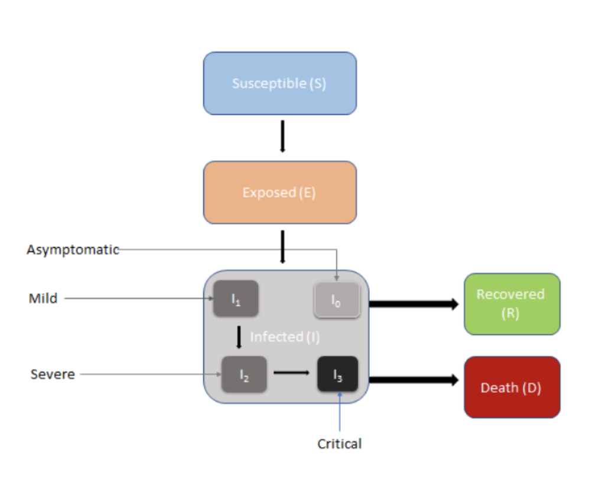

So depending on the intensity of the outbreak, a fraction of susceptible population gets exposed. People from the exposed segment either move into Asymptomatic or into Mild, which further either moves to Recovered or to Severe and so and so forth. Eventually, people from critical compartment either move into Recovered or unfortunately, dead compartment.

#### Simulation

[figure not shown]

Amidst great research papers recently published, parameters were referenced from one of such sources, which is cited below. To project the impact of Social Distancing — beta was derived from the COVID dataset of New Zealand. Similarly, to project the impact of Early Detection — gamma was derived from the COVID dataset of South Korea.

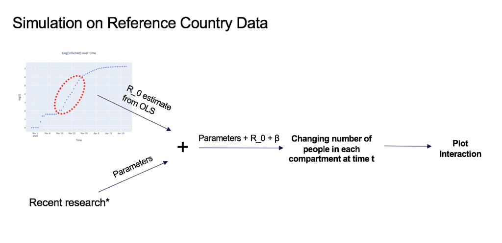

*Simulation Structure*

This final set of parameters along with the COVID dataset of the state of New York was then used to plot the curve for New York.

[video not shown]

Feel free to check out our GitHub page for codes and other detailed information.

[Github](https://github.com/sahil350/BA-project)